# 計算Black-Scholes選擇權隱含波動度

周育呈

2023-11-12

# 1. 前言

這是碩一下$\color{red}{數值分析}$有上過的內容，這篇的程式碼是從老師檔案改的，我把計算過程寫成一個function(Calculator)-ImpliedVolatility()，使用上更方便，ImpliedVolatility的程式碼我一樣放在雲端的另一個檔案。  
其實網路上直接Google- $Implied \ Volatility \ Calculator$就有很多網站可以計算隱含波動度了，這篇side-profect的計算結果以網站計算結果來檢驗是否正確。  
如果想在R語言裡計算選擇權相關的數值，我有找到一個套件$\bf derivmkts$可以用，使用方式也會在下面提到。

# 2. Arguments

我寫了一個函數-ImpliedVolatility，可以計算隱含波動度跟選擇權價格，這裡說明如何輸入arguments。

- 2.1 Mode  
  輸入字串’Price’ 或 ‘Vol’，選擇要計算選擇權價格還是隱含波動度。
- 2.2 type  
  輸入字串’Call’ 或 ‘Put’，選擇要計算買權還是賣權。
- 2.3 ss  
  輸入現貨價格。
- 2.4 kk  
  輸入履約價。
- 2.5 tt  
  輸入選擇權到期天數，單位為天。
- 2.6 rr  
  輸入無風險利率，如利率為1.1%，則輸入1.1，不是輸入0.011。
- 2.7 qq  
  輸入股息殖利率，如股息殖利率為0.58%，則輸入0.58，不是輸入0.0058。
- 2.8 OptionPrice  
  輸入選擇權價格，如果Mode = ‘Price’，則不需輸入。
- 2.9 sig  
  輸入現貨報酬率的波動度，如波動度為20%，則輸入20，不是輸入0.2，如果Mode = ‘Vol’，則不需輸入。
- 2.10 xstart  
  這是解數值解的起點，是nleqslv的argument，有default值=0.1，原則上不需輸入。

# 3. Output

輸入完arguments後，ImpliedVolatility會直接在Console顯示輸入的內容跟計算的值(選擇權價格或隱含波動度)。  
舉4個例子，計算Call、Put的價格跟隱含波動度各1個。

## 3.1 Call-Vol

```r
ImpliedVolatility(Mode = "Vol",sig = 20,type = "Call", ss = 88,
                  kk = 95,tt = 51,rr = 3.2,qq = 0,OptionPrice = 3.52)
```

```
##  Option Type : Call
##  Underlying Price =  88
##  Strike Price =  95
##  Interest Rate =  3.2 %
##  Days to Expiration =  51
##  Dividend Yield =  0 %
##  Option Price =  3.52
##  ------------------------------
##  Implied Volatility =  46.112 %
```

## 3.2 Put-Vol

```r
ImpliedVolatility(Mode = "Vol",sig = 20,type = "Put", ss = 147,
                  kk = 152,tt = 112,rr = 1.65,qq = 0.45,OptionPrice = 4.5)
```

```
##  Option Type : Put
##  Underlying Price =  147
##  Strike Price =  152
##  Interest Rate =  1.65 %
##  Days to Expiration =  112
##  Dividend Yield =  0.45 %
##  Option Price =  4.5
##  ------------------------------
##  Implied Volatility =  3.362 %
```

## 3.3 Call-Price

```r
ImpliedVolatility(Mode = "Price",sig = 20,type = "Call", ss = 50,
                         kk = 52,tt = 100,rr = 2.2,qq = 1.2,OptionPrice = 2.41)
```

```
##  Underlying Price =  50
##  Strike Price =  52
##  Interest Rate =  2.2 %
##  Days to Expiration =  100
##  Dividend Yield =  1.2 %
##  Volatility =  20 %
##  -------------------------
##  Call Price =  1.3204
##  Put Price =  3.1721
```

## 3.4 Put-Price

```r
ImpliedVolatility(Mode = "Price",sig = 25,type = "Put", ss = 170,
                  kk = 165,tt = 145,rr = 2.4,qq = 5.2,OptionPrice = 5.89)
```

```
##  Underlying Price =  170
##  Strike Price =  165
##  Interest Rate =  2.4 %
##  Days to Expiration =  145
##  Dividend Yield =  5.2 %
##  Volatility =  25 %
##  -------------------------
##  Call Price =  11.9781
##  Put Price =  8.8882
```

# 4. 檢驗

Google : implied volatility calculator，我選了3個網址來檢驗隱含波動度的計算結果。以下為網址:  
https://www.option-price.com/implied-volatility.php (只有這個網址可計算包含股息殖利率的隱含波動度)  
https://vindeep.com/Derivatives/ImpVolCalc.aspx  
https://www.ultimateoptionscalculator.com/calculators/iv

Google : black-scholes calculator，我選了3個網址來檢驗選擇權價格的計算結果。以下為網址:  
https://goodcalculators.com/black-scholes-calculator/  
https://www.omnicalculator.com/finance/black-scholes  
https://billmei.github.io/SimpleBlackScholes/

## 4.1 Call-Vol

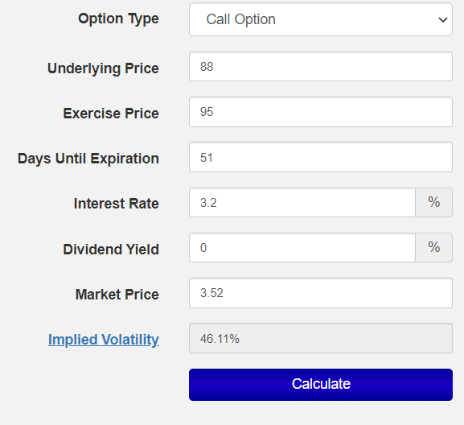

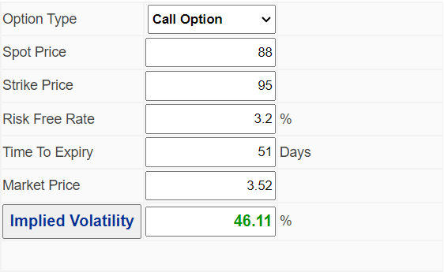

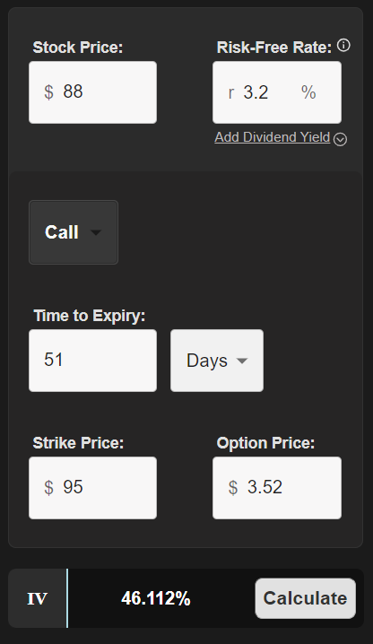

## 4.2 Put-Vol

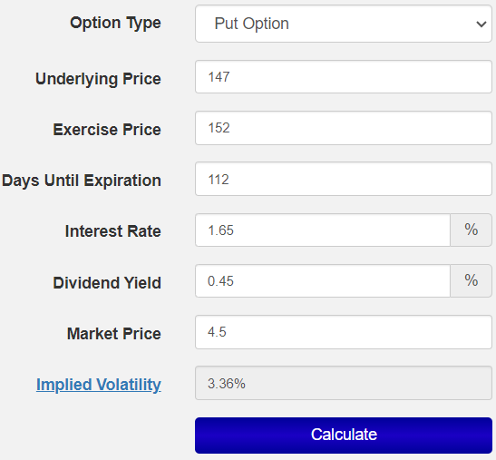

## 4.3 Call-Price

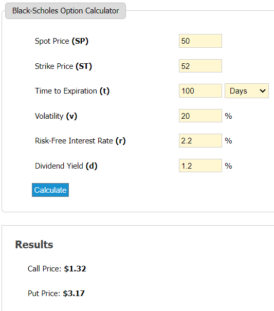

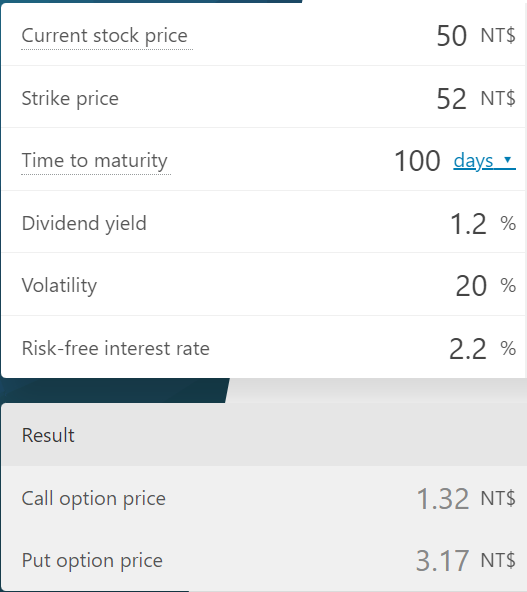

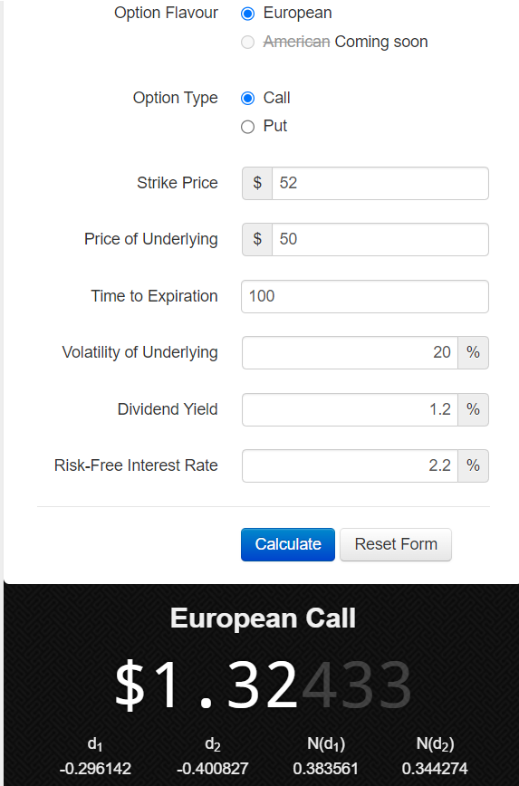

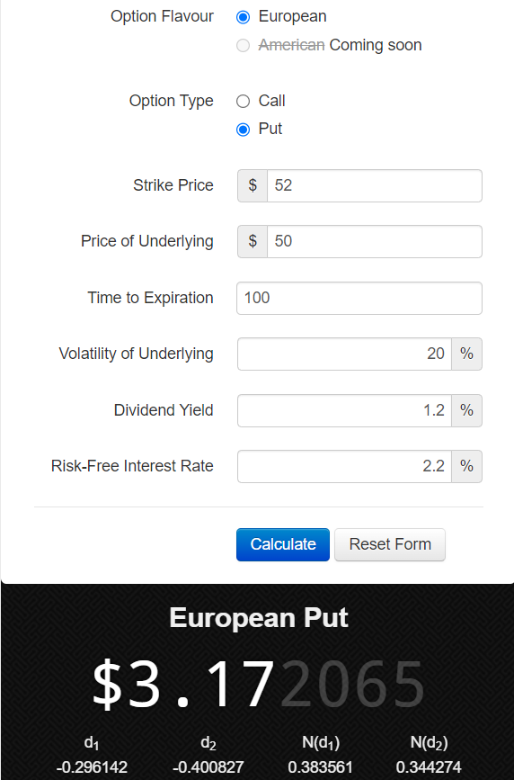

## 4.4 Put-Price

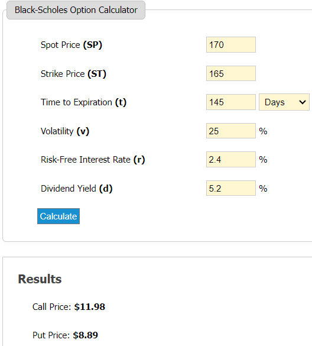

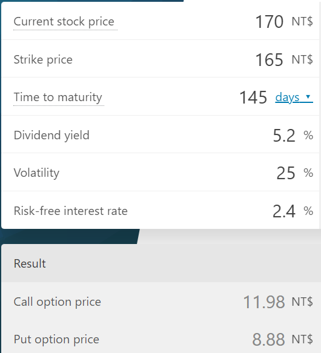

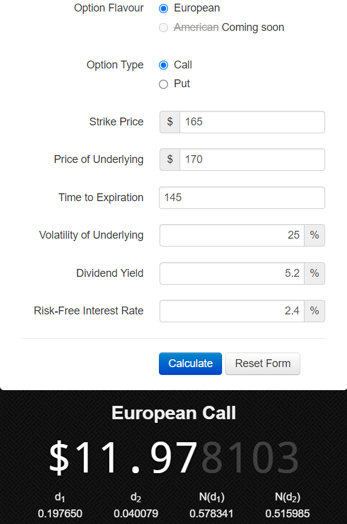

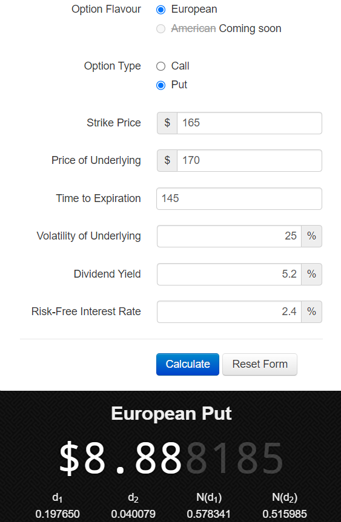

# 5. $\bf derivmkts$套件

套件介紹：A set of pricing and expository functions that should be useful in teaching a course on financial derivatives.  
網址：https://www.rdocumentation.org/packages/derivmkts/versions/0.2.5  
這套建能計算的東西很多，我以下計算ImpliedVolatility、OptionPrice、Greeks。  
以$3. \ Output$的選擇權來計算，注意套件的的利率相關數字要輸入原本數值，天數為年，可以直接輸入分數。

## 5.1 ImpliedVolatility

- Call：bscallimpvol()

```r
bscallimpvol(s = 88,k = 95,r = 0.032,tt = 51/365,d = 0,price = 3.52)
```

```
## [1] 0.4611156
```

- Put ：bsputimpvol()

```r
bsputimpvol(s = 147,k = 152,r = 0.0165,tt = 112/365,d = 0.0045,price = 4.5)
```

```
## [1] 0.03362449
```

## 5.2 OptionPrice

- Call：bscall()

```r
bscall(s = 50,k = 52,v = 0.2,r = 0.022,tt = 100/365,d = 0.012)
```

```
## [1] 1.320434
```

- Put：bsput()

```r
bsput(s = 170,k = 165,v = 0.25,r = 0.024,tt = 145/365,d = 0.052)
```

```
## [1] 8.888185
```

## 5.3 Greeks

函數網址：  
https://www.rdocumentation.org/packages/derivmkts/versions/0.2.5/topics/greeks

- Call：greeks(bscall(s, k, v, r, tt, d))

```r
greeks(bscall(s = 50,k = 52,v = 0.2,r = 0.022,tt = 100/365,d = 0.012))
```

```
##                 bscall
## Premium     1.32043372
## Delta       0.38230196
## Gamma       0.07270843
## Vega        0.09960061
## Rho         0.04875251
## Theta      -0.01040418
## Psi        -0.05237013
## Elasticity 14.47637841
```

- Put：greeks(bsput(s, k, v, r, tt, d))

```r
greeks(bsput(s = 170,k = 165,v = 0.25,r = 0.024,tt = 145/365,d = 0.052))
```

```
##                  bsput
## Premium     8.88818521
## Delta      -0.41303822
## Gamma       0.01430621
## Vega        0.41062189
## Rho        -0.31425148
## Theta      -0.04020048
## Psi         0.27894225
## Elasticity -7.89998136
```

謝謝你看到這~